# Machine Learning Midterm Coursework

## Machine Learning

```python
import pandas as pd
import numpy as np
import seaborn as sns
import matplotlib.pyplot as plt
from sklearn.preprocessing import LabelEncoder
from sklearn.preprocessing import StandardScaler
from sklearn.model_selection import train_test_split, cross_validate, StratifiedKFold
from sklearn.linear_model import LogisticRegression
from sklearn.tree import DecisionTreeClassifier
from imblearn.over_sampling import RandomOverSampler, SMOTE
from imblearn.under_sampling import RandomUnderSampler
from sklearn.pipeline import Pipeline as SklearnPipeline
from imblearn.pipeline import Pipeline as ImblearnPipeline

from sklearn.metrics import classification_report, confusion_matrix, accuracy_score, precision_score, recall_score, f1_score

from sklearn.exceptions import UndefinedMetricWarning

import warnings
warnings.filterwarnings("ignore", category=FutureWarning)
warnings.filterwarnings("ignore", category=UndefinedMetricWarning)
```

```python
# loading dataset
df = pd.read_csv(r'C:\Users\harsh\Dropbox\1. UNIVERSITY\5. Year 3 Modules\Y3S1 Modules\2. Machine Learning and Neural Networks\dataset\dataset.csv')
```

### Exploratory Data Analysis (EDA)

#### Basic Overview

```python
#number of rows and columns in the dataset
df.shape
```

```
(43400, 12)
```

```python
# overview of the dataset
df
```

|  | id | gender | age | hypertension | heart_disease | ever_married | work_type | Residence_type | avg_glucose_level | bmi | smoking_status | stroke |
| --- | --- | --- | --- | --- | --- | --- | --- | --- | --- | --- | --- | --- |
| 0 | 30669 | Male | 3.0 | 0 | 0 | No | children | Rural | 95.12 | 18.0 | NaN | 0 |
| 1 | 30468 | Male | 58.0 | 1 | 0 | Yes | Private | Urban | 87.96 | 39.2 | never smoked | 0 |
| 2 | 16523 | Female | 8.0 | 0 | 0 | No | Private | Urban | 110.89 | 17.6 | NaN | 0 |
| 3 | 56543 | Female | 70.0 | 0 | 0 | Yes | Private | Rural | 69.04 | 35.9 | formerly smoked | 0 |
| 4 | 46136 | Male | 14.0 | 0 | 0 | No | Never_worked | Rural | 161.28 | 19.1 | NaN | 0 |
| ... | ... | ... | ... | ... | ... | ... | ... | ... | ... | ... | ... | ... |
| 43395 | 56196 | Female | 10.0 | 0 | 0 | No | children | Urban | 58.64 | 20.4 | never smoked | 0 |
| 43396 | 5450 | Female | 56.0 | 0 | 0 | Yes | Govt_job | Urban | 213.61 | 55.4 | formerly smoked | 0 |
| 43397 | 28375 | Female | 82.0 | 1 | 0 | Yes | Private | Urban | 91.94 | 28.9 | formerly smoked | 0 |
| 43398 | 27973 | Male | 40.0 | 0 | 0 | Yes | Private | Urban | 99.16 | 33.2 | never smoked | 0 |
| 43399 | 36271 | Female | 82.0 | 0 | 0 | Yes | Private | Urban | 79.48 | 20.6 | never smoked | 0 |

43400 rows × 12 columns

```python
#summary of dataset structure
df.info()
```

```
<class 'pandas.core.frame.DataFrame'>
RangeIndex: 43400 entries, 0 to 43399
Data columns (total 12 columns):
 #   Column             Non-Null Count  Dtype
---  ------             --------------  -----
 0   id                 43400 non-null  int64
 1   gender             43400 non-null  object
 2   age                43400 non-null  float64
 3   hypertension       43400 non-null  int64
 4   heart_disease      43400 non-null  int64
 5   ever_married       43400 non-null  object
 6   work_type          43400 non-null  object
 7   Residence_type     43400 non-null  object
 8   avg_glucose_level  43400 non-null  float64
 9   bmi                41938 non-null  float64
 10  smoking_status     30108 non-null  object
 11  stroke             43400 non-null  int64
dtypes: float64(3), int64(4), object(5)
memory usage: 4.0+ MB
```

```python
#summary statistics of numeric columns
df.describe()
```

|  | id | age | hypertension | heart_disease | avg_glucose_level | bmi | stroke |
| --- | --- | --- | --- | --- | --- | --- | --- |
| count | 43400.000000 | 43400.000000 | 43400.000000 | 43400.000000 | 43400.000000 | 41938.000000 | 43400.000000 |
| mean | 36326.142350 | 42.217894 | 0.093571 | 0.047512 | 104.482750 | 28.605038 | 0.018041 |
| std | 21072.134879 | 22.519649 | 0.291235 | 0.212733 | 43.111751 | 7.770020 | 0.133103 |
| min | 1.000000 | 0.080000 | 0.000000 | 0.000000 | 55.000000 | 10.100000 | 0.000000 |
| 25% | 18038.500000 | 24.000000 | 0.000000 | 0.000000 | 77.540000 | 23.200000 | 0.000000 |
| 50% | 36351.500000 | 44.000000 | 0.000000 | 0.000000 | 91.580000 | 27.700000 | 0.000000 |
| 75% | 54514.250000 | 60.000000 | 0.000000 | 0.000000 | 112.070000 | 32.900000 | 0.000000 |
| max | 72943.000000 | 82.000000 | 1.000000 | 1.000000 | 291.050000 | 97.600000 | 1.000000 |

```python
#stroke imbalance
print(df['stroke'].value_counts())
print(df['stroke'].value_counts(normalize=True) * 100)
```

```
stroke
0    42617
1      783
Name: count, dtype: int64
stroke
0    98.195853
1     1.804147
Name: proportion, dtype: float64
```

#### Graphical Overview

##### Continuous Features vs Stroke

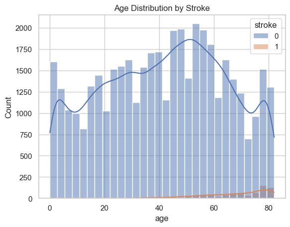

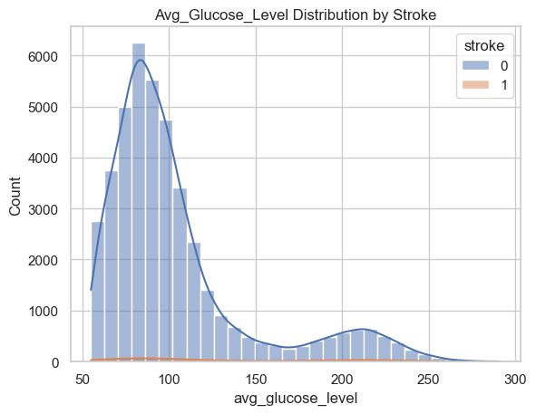

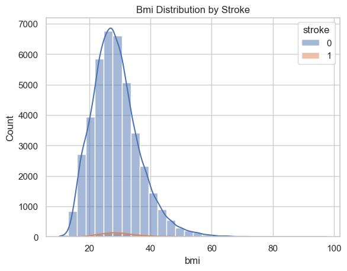

```python
continuous_columns = ['age', 'avg_glucose_level', 'bmi']
for col in continuous_columns:
    sns.histplot(data=df, x=col, hue='stroke', kde=True, bins=30)
    plt.title(f"{col.title()} Distribution by Stroke")
    plt.show()
```

##### Binary Features vs Stroke

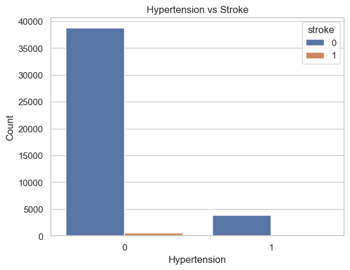

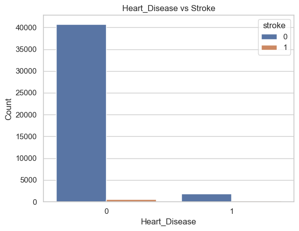

```python
binary_columns = ['hypertension', 'heart_disease']

for col in binary_columns:
    sns.countplot(data=df, x=col, hue=df['stroke'].astype(str))
    plt.xlabel(col.title())
    plt.ylabel("Count")
    plt.title(f"{col.title()} vs Stroke")
    plt.show()
```

##### Other Features vs Stroke

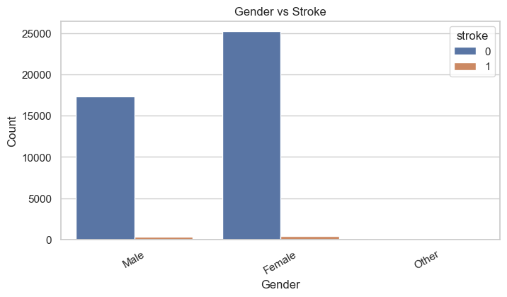

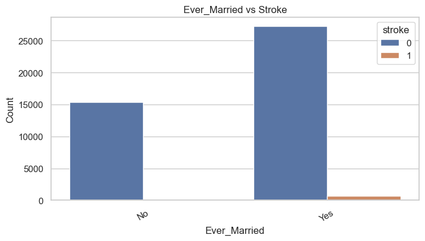

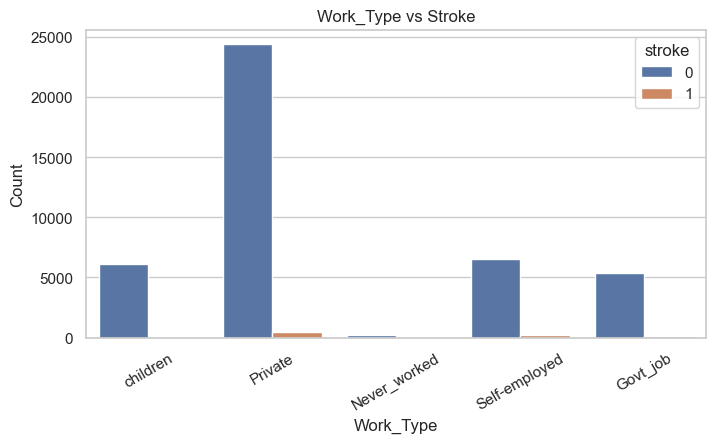

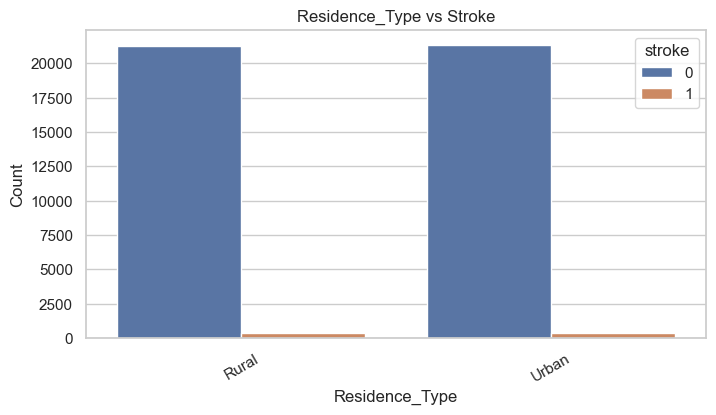

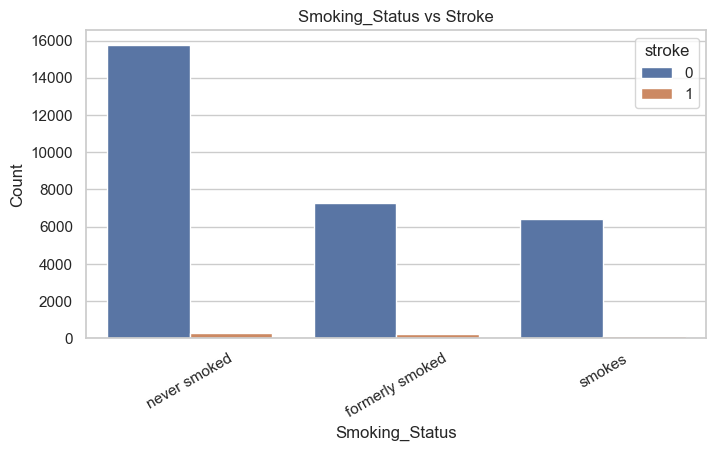

```python
other_columns = ['gender', 'ever_married', 'work_type', 'Residence_type', 'smoking_status']

for col in other_columns:
    plt.figure(figsize=(8, 4))
    sns.countplot(data=df, x=col, hue=df['stroke'].astype(str))
    plt.xlabel(col.title())
    plt.ylabel("Count")
    plt.xticks(rotation=30)
    plt.title(f"{col.title()} vs Stroke")
    plt.show()
```

##### Correlation Matrix

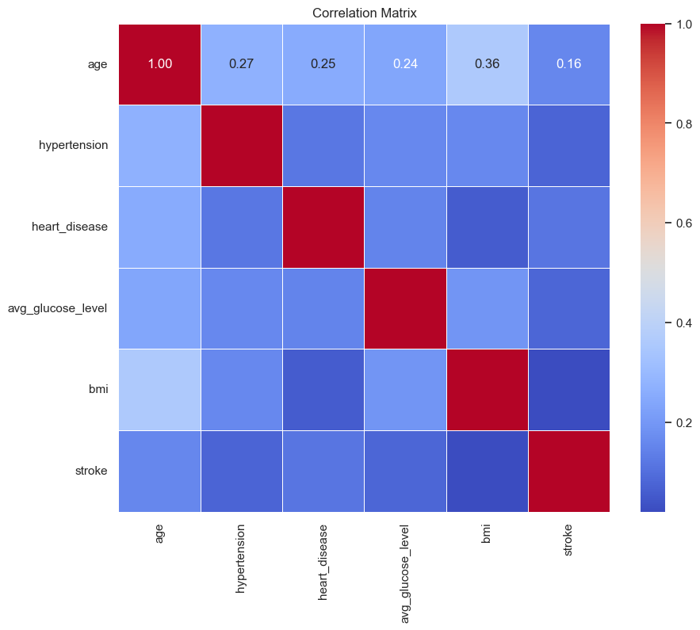

```python
#drop id column
if 'id' in df.columns:
    df = df.drop('id', axis=1)

numeric_columns = df.select_dtypes(include=['int64', 'float64'])
correlation_matrix = numeric_columns.corr()

plt.figure(figsize=(10, 8))
sns.heatmap(correlation_matrix, annot=True, cmap='coolwarm', fmt=".2f", linewidths=0.5)
plt.title("Correlation Matrix")
plt.show()
```

##### Stroke Imbalance

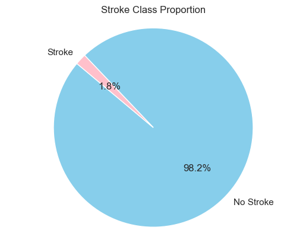

```python
proportion = df['stroke'].value_counts()

plt.pie(proportion, labels=['No Stroke', 'Stroke'], colors=['skyblue', 'pink'], autopct='%1.1f%%', startangle=140)
plt.title("Stroke Class Proportion")
plt.axis('equal')
plt.show()
```

### Preparing Dataset

##### Dropped ID Column

```python
#dropped id column earlier
df.columns
```

```
Index(['gender', 'age', 'hypertension', 'heart_disease', 'ever_married',
       'work_type', 'Residence_type', 'avg_glucose_level', 'bmi',
       'smoking_status', 'stroke'],
      dtype='object')
```

##### Checking & Fixing Missing Values

```python
df.isnull().sum()
```

```
gender                   0
age                      0
hypertension             0
heart_disease            0
ever_married             0
work_type                0
Residence_type           0
avg_glucose_level        0
bmi                   1462
smoking_status       13292
stroke                   0
dtype: int64
```

```python
#median for bmi
df['bmi'] = df['bmi'].fillna(df['bmi'].median())

#unknown for smoking_status
df['smoking_status'] = df['smoking_status'].fillna('Unknown')

df.isnull().sum()
```

```
gender               0
age                  0
hypertension         0
heart_disease        0
ever_married         0
work_type            0
Residence_type       0
avg_glucose_level    0
bmi                  0
smoking_status       0
stroke               0
dtype: int64
```

##### Checking for Duplicate Rows

```python
print("Duplicates:", df.duplicated().sum())
```

```
Duplicates: 0
```

##### Encoding Categorical Columns

```python
#encode all object-type columns
columns_to_encode = ['gender', 'ever_married', 'work_type', 'Residence_type', 'smoking_status']

le = LabelEncoder()

for col in columns_to_encode:
    df[col] = le.fit_transform(df[col])

df.head()
```

|  | gender | age | hypertension | heart_disease | ever_married | work_type | Residence_type | avg_glucose_level | bmi | smoking_status | stroke |
| --- | --- | --- | --- | --- | --- | --- | --- | --- | --- | --- | --- |
| 0 | 1 | 3.0 | 0 | 0 | 0 | 4 | 0 | 95.12 | 18.0 | 0 | 0 |
| 1 | 1 | 58.0 | 1 | 0 | 1 | 2 | 1 | 87.96 | 39.2 | 2 | 0 |
| 2 | 0 | 8.0 | 0 | 0 | 0 | 2 | 1 | 110.89 | 17.6 | 0 | 0 |
| 3 | 0 | 70.0 | 0 | 0 | 1 | 2 | 0 | 69.04 | 35.9 | 1 | 0 |
| 4 | 1 | 14.0 | 0 | 0 | 0 | 1 | 0 | 161.28 | 19.1 | 0 | 0 |

##### Split Features and Labels

```python
#keep all input features (remove target)
X = df.drop('stroke', axis=1)

#store the labels
y = df['stroke']
```

##### Split into Train and Test

```python
#stratify=y to ensure label balance (e.g., test set not getting any stroke=1 cases)
X_train, X_test, y_train, y_test = train_test_split(X, y, test_size=0.2, stratify=y, random_state=42)
```

### Adressing Class Imbalance

#### 1. Logistic Regression - Baseline, Oversampling, Undersampling, SMOTE (Cross-Validation)

##### 1.1 Process

```python
#metrics to evaluate
metrics = ['accuracy', 'precision', 'recall', 'f1']

#use StratifiedKFold to keep class distribution similar in each fold
cross_validation = StratifiedKFold(n_splits=5, shuffle=True, random_state=42)

#dictionary of resampling strategies including baseline
resamplers = {
    "Baseline": None,
    "Random Oversampling": RandomOverSampler(),
    "Random Undersampling": RandomUnderSampler(),
    "SMOTE": SMOTE()
}

#loop through each resampling strategy
for name, resampler in resamplers.items():
    print(f"\nResults for {name}:")

    #baseline
    if resampler is None:
        #use regular pipeline
        pipeline = SklearnPipeline([
            ('scaler', StandardScaler()),
            ('logreg', LogisticRegression(random_state=42))
        ])

    #oversampling, undersampling, SMOTE
    else:
        pipeline = ImblearnPipeline([
            ('scaler', StandardScaler()),
            ('resampler', resampler),
            ('logreg', LogisticRegression(random_state=42))
        ])

    #perform cross-validation
    outcome = cross_validate(
        pipeline,
        X_train, y_train,
        cv=cross_validation,
        scoring=metrics
    )

    #print average scores
    for metric in metrics:
        avg_score = outcome[f'test_{metric}'].mean()
        print(f"{metric.capitalize()}: {avg_score:.4f}")
```

```
Results for Baseline:
Accuracy: 0.9820
Precision: 0.0000
Recall: 0.0000
F1: 0.0000

Results for Random Oversampling:
Accuracy: 0.7473
Precision: 0.0544
Recall: 0.7956
F1: 0.1019

Results for Random Undersampling:
Accuracy: 0.7442
Precision: 0.0535
Recall: 0.7908
F1: 0.1002

Results for SMOTE:
Accuracy: 0.7559
Precision: 0.0559
Recall: 0.7908
F1: 0.1045
```

##### 1.2 Visualising Metrics

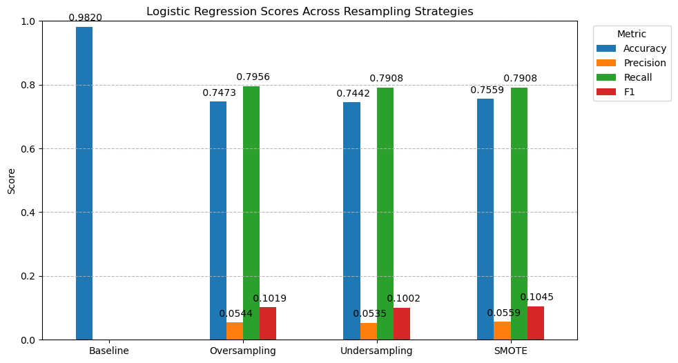

```python
#outcome
outcome_dict = {
    "Baseline": [0.9820, 0.0000, 0.0000, 0.0000],
    "Oversampling": [0.7473, 0.0544, 0.7956, 0.1019],
    "Undersampling": [0.7442, 0.0535, 0.7908, 0.1002],
    "SMOTE": [0.7559, 0.0559, 0.7908, 0.1045]
}

#metric labels
metrics = ['Accuracy', 'Precision', 'Recall', 'F1']

#convert to DataFrame for plotting
df = pd.DataFrame(outcome_dict, index=metrics)

#plot bar chart
ax = df.T.plot(kind='bar', figsize=(10, 6))
plt.title("Logistic Regression Scores Across Resampling Strategies")
plt.xticks(rotation=0)
plt.ylabel("Score")
plt.ylim(0, 1)
plt.grid(axis='y', linestyle='--', alpha=0.9)

#add labels only if the bar value > 0
for container in ax.containers:
    labels = [f'{v: .4f}' if v > 0 else '' for v in container.datavalues]
    ax.bar_label(container, labels=labels, label_type='edge', padding=4)

#add legend
plt.legend(title="Metric", bbox_to_anchor=(1.02, 1), loc='upper left')

plt.show()
```

##### 1.3 Interpretation

Baseline:

- The baseline model achieved high accuracy but failed to correctly identify minority class cases (stroke = 1).
- This is due to the imbalanced dataset.
- The model predicts mostly the majority class to achieve high accuracy, which is misleading.

Oversampling:

- Accuracy: Dropped to 0.7473 which is expected as the model no longer predicts only the majority class.
- Precision: Low, indicating many false positives when prediciting the minority class.
- Recall: High, showing the model is now able to detect most of the actual minority class cases (stroke = 1).
- F1-Score: Improved (0.1019) compared to baseline, a better balance between precision and recall.

Undersampling:

- Accuracy: Slightly lower (0.7442) due to training on a reduced dataset.
- Precision: Low, indicating many false positives when prediciting the minority class.
- Recall: High, showing the model is now able to detect most of the actual minority class cases (stroke = 1).
- F1-Score: Lower (0.1002) than oversampling.

SMOTE:

- Accuracy: Slightly better (0.7559) than oversampling and undersampling.
- Precision: Slightly improved (0.0559), indicating fewer false positives than other resampling strategies.
- Recall: High, showing the model is now able to detect most of the actual minority class cases (stroke = 1).
- F1-Score: Highest among all (0.1045), suggesting SMOTE achieved the most balanced performance overall.